# Part II - (Prosper Loan Data Explanatory Analysis)

## by (Oni Samuel Oluwapelumi)

## Investigation Overview

> My interest would be exploring the LoanOriginalAmount. I would also love to know the factors that affects the borrower's loan amount or if there is something borrowers have in common i.e State, Occupation, Employment status, etc. What is the major influence as to the amount a borrower can get?

## (Visualization 1) - Borrowers state

> For the first visualization, we would look at the borrowers state category. The aim is to get the states the borrowers came from and what state tops the chart?

> For this visualization, California has the highest number, double the percentage compared to any other state. followed by Texas, New York, and Florida follows suit.

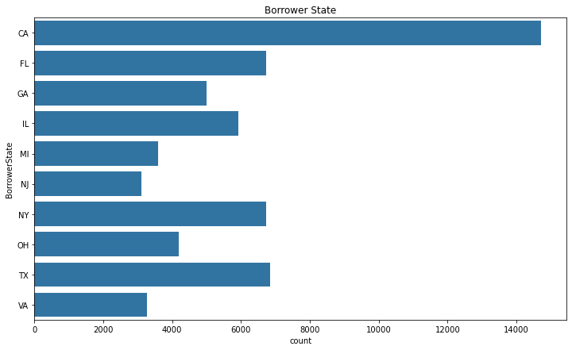

## (Visualization 2) - Relationship between Loan Amount and Income Range

> For this Visualization, Using a boxplot we will visualize if the IncomeRange of the borrowers affect the LoanOriginalAmount.

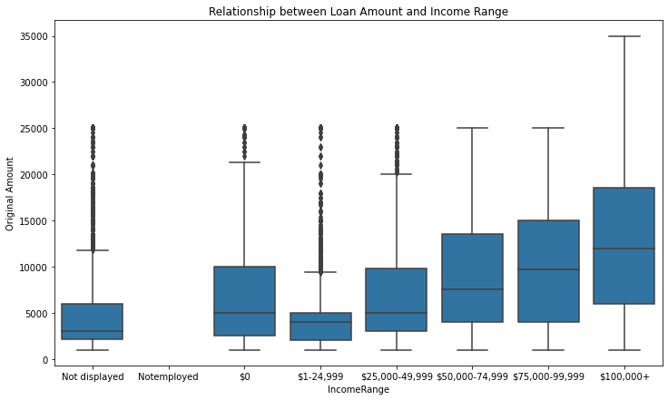

## (Visualization 3) - Employment Status

> Finally, this visualization will give you a pictorial representation of the category of people in variable 'EmploymentStatus'. we get to see people that took the highest loan.

> And we can see that the borrowers that are Employed rank the highest. And it is understandable why part-time, Not-employed and Retired took the least loan.

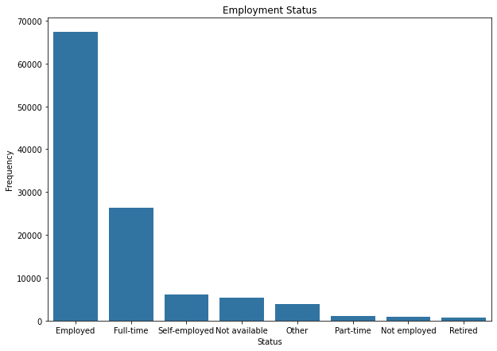